# (Fordgo bike data exploration)

## by (Hager Sayed)

This document explores a dataset containing the trip data of the fordgo bike.

the distribution of members gender using piecharts

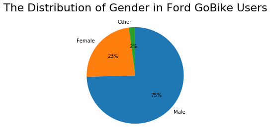

the percentage of male users is the hieghest as 75% of users are males,23% are females and 2% are others

now we will see the distribution of user types

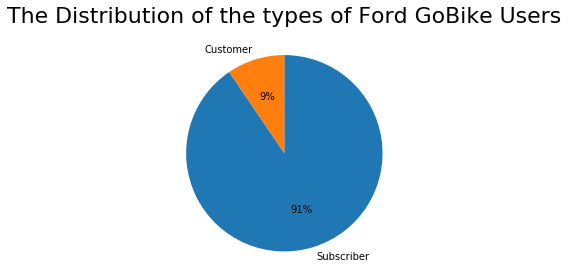

from the previous plots the majority of the users are subscribers (91% of users are subscribers and 9% customers)

now we will see the distribution of tha ages of the users

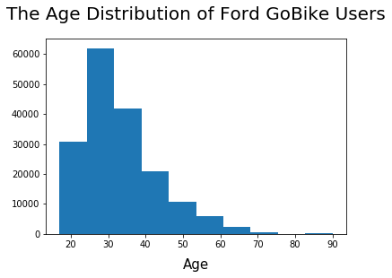

the mean age of the members is 33 years old and number of members decreases as age goes higher

now we will the distribution of the trips duaration in minutes

```
(0, 100)
```

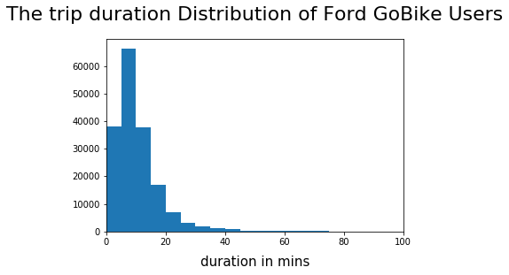

from the duaration distribution the majority of the ride are less than 20 minutes and as the duration increases the number of users decreases

we will see the relationship between user age and duration of rides

```
(0, 200)
```

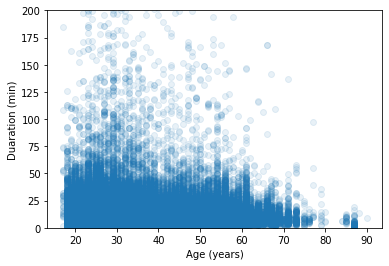

from the scatter plot most users of different ages ride less than 50 minutes Higher durations are clocked by younger members.

studying the usage of different types of customers during the week

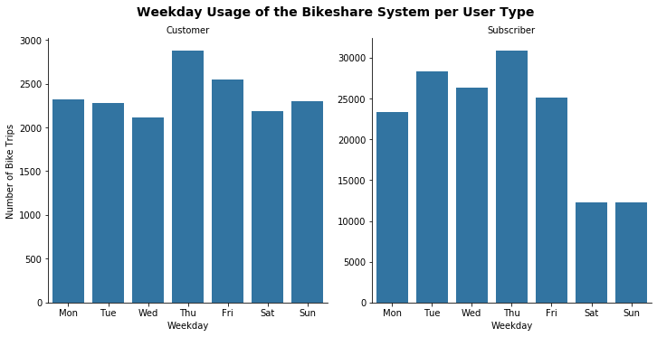

both customers and users use the bikes the most on thursday but on saturday and sunday subscribers usage rate is much less than users but for most of the remaining days there is no much difference

the relationship between user_type and duration

```
(0, 200)
```

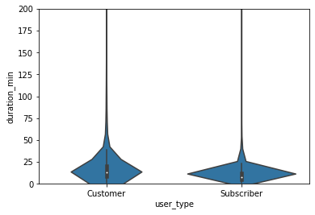

from the violin plot a larger percentage of customers are taking longer rides duration compared to subscripers

the relationship between member age , gender and the duarion of the trip

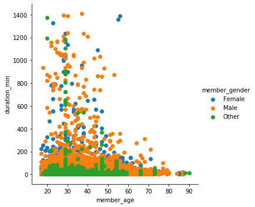

from the scatter plot we can tell that higher duration are occupied by ages mostly less than 60 and there is no obvious effect on duration based on gender

analyzing the distributions between customer and subscriber, based on gender and weekday usage.

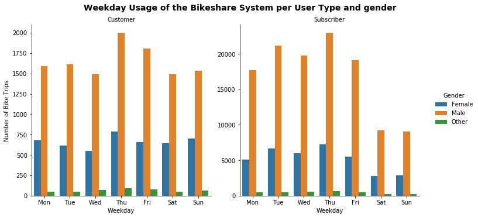